# Project 3

Umesh Rao & Luke Perkins

2022-11-11

# Data Reading and Formatting

To begin, we load in relevant packages with `library()` statements. Then, `read_csv()` and a relative path is used to read in the data. `pivot_longer()` is used to reshape the six dummy variables indicating the data channel into one column. The `cols` argument specifies the data to restructure from rows to columns, `names_to` names the column containing the column names from the original data, and `values_to` names the column containing the actual values being reshaped. `filter()` is then used to subset the data to only rows where the reshaped values are 1, as in the ‘long’ data format, those are the only rows of interest. The `temp` variable containing the indicator values is then dropped and the object is saved.

```r
library(tidyverse)
library(caret)
library(class)
library(corrplot)

news_pop <- read_csv("OnlineNewsPopularity.csv") %>%
  pivot_longer(cols = 14:19,
               names_to = "data_channel",
               values_to = "temp") %>%
  filter(temp == 1) %>%
  select(-temp)
```

# R Markdown Automation

The R Markdown is automated by generating separate reports and analyses by each level of a parameter, in this case, the `data_channel`. First, the `unique()` function is used to generate a list of unique values for `data_channel`. Then, `paste0` concatenates the file extension to the end of each channel ID. `lapply()` takes each concatenated name and extension, and applies the `list` function to convert each one into a named list object with one element. A tibble is then created containing the the output file name and the one item list of the parameterized `data_channel` value. The full data set `news_pop` then uses `filter()` to subset records to the `data_channel` variable currently reflected in the `params` argument in the R Markdown document, and is saved as `channel`.

```r
#r markdown automation. Needs to run to get reports object before running the 2nd chunk below in console
channelIDs <- unique(news_pop$data_channel)
output_file <- paste0(channelIDs, ".html")
param_names <- lapply(channelIDs, FUN = function(x){list(channel = x)})
reports <- tibble(output_file, param_names)
channel <- news_pop %>% filter(data_channel == params$channel)
```

```r
#run this in console for individual channel
rmarkdown::render("testparams.Rmd",
                  output_file = "data_channel_is_entertainment.html",
                  params = list(channel = "data_channel_is_entertainment"))

#run this in console for all channels
library(rmarkdown)

apply(reports, MARGIN = 1,
      FUN = function(x){
        render(input = "testparams.Rmd", output_file = x[[1]], params = x[[2]])
      }
)
```

# Summarizations

## Correlations

One strategy in exploring the data is to use a correlation matrix to view potential linear relationships as a baseline. Using `select()`, the full data set is subset to drop `url`, `timedelta`, which is indicated in the variable descriptions as non-predictive, and `data_channel`, as each analysis is split on the level of this variable, so the values will all be the same. The `cor()` function creates a correlation matrix using the Pearson correlation coefficient, and the matrix is saved as `cor_mat`.

Because the number of variables is large, the `png()` function is called to adjust the `width` and `height` of the correlation plot, and the file is saved as “corrplot.png”. The `corr_plot()` function is used to create a visualization of the matrix, taking the matrix itself as the first argument. The `type` argument is given as `"lower"` to indicate the display should be the lower half, `tl.pos` as `"ld"` specifies the text label positions as left and diagonal, `title` is used to give a relevant title, and `mar` adjusts the margins so that the title is visible. The `dev.off()` function closes the graphics device so that the image can render, and `include_graphics()` prints the plot image.

```r
summary(channel)
```

```
##      url              timedelta     n_tokens_title n_tokens_content
##  Length:7057        Min.   :  8.0   Min.   : 2     Min.   :   0.0
##  Class :character   1st Qu.:146.0   1st Qu.:10     1st Qu.: 255.0
##  Mode  :character   Median :298.0   Median :11     Median : 433.0
##                     Mean   :331.9   Mean   :11     Mean   : 607.5
##                     3rd Qu.:519.0   3rd Qu.:12     3rd Qu.: 805.0
##                     Max.   :731.0   Max.   :18     Max.   :6505.0
##  n_unique_tokens    n_non_stop_words   n_non_stop_unique_tokens
##  Min.   :  0.0000   Min.   :   0.000   Min.   :  0.0000
##  1st Qu.:  0.4701   1st Qu.:   1.000   1st Qu.:  0.6234
##  Median :  0.5421   Median :   1.000   Median :  0.6917
##  Mean   :  0.6316   Mean   :   1.119   Mean   :  0.7632
##  3rd Qu.:  0.6174   3rd Qu.:   1.000   3rd Qu.:  0.7597
##  Max.   :701.0000   Max.   :1042.000   Max.   :650.0000
##    num_hrefs      num_self_hrefs      num_imgs         num_videos
##  Min.   :  0.00   Min.   : 0.000   Min.   :  0.000   Min.   : 0.000
##  1st Qu.:  4.00   1st Qu.: 1.000   1st Qu.:  1.000   1st Qu.: 0.000
##  Median :  7.00   Median : 3.000   Median :  1.000   Median : 1.000
##  Mean   : 10.69   Mean   : 3.497   Mean   :  6.318   Mean   : 2.546
##  3rd Qu.: 13.00   3rd Qu.: 5.000   3rd Qu.:  8.000   3rd Qu.: 1.000
##  Max.   :304.00   Max.   :40.000   Max.   :128.000   Max.   :74.000
##  average_token_length  num_keywords      kw_min_min       kw_max_min
##  Min.   :0.000        Min.   : 2.000   Min.   : -1.00   Min.   :     0
##  1st Qu.:4.426        1st Qu.: 5.000   1st Qu.: -1.00   1st Qu.:   419
##  Median :4.583        Median : 7.000   Median : -1.00   Median :   603
##  Mean   :4.477        Mean   : 6.925   Mean   : 20.93   Mean   :  1056
##  3rd Qu.:4.751        3rd Qu.: 8.000   3rd Qu.:  4.00   3rd Qu.:   924
##  Max.   :7.696        Max.   :10.000   Max.   :294.00   Max.   :138700
##    kw_avg_min        kw_min_max       kw_max_max       kw_avg_max
##  Min.   :   -1.0   Min.   :     0   Min.   :     0   Min.   :     0
##  1st Qu.:  124.8   1st Qu.:     0   1st Qu.:843300   1st Qu.:180200
##  Median :  209.8   Median :  1500   Median :843300   Median :232414
##  Mean   :  286.4   Mean   : 13281   Mean   :766981   Mean   :243994
##  3rd Qu.:  325.0   3rd Qu.: 11600   3rd Qu.:843300   3rd Qu.:303860
##  Max.   :34855.1   Max.   :210300   Max.   :843300   Max.   :670750
##    kw_min_avg     kw_max_avg       kw_avg_avg    self_reference_min_shares
##  Min.   :   0   Min.   :     0   Min.   :    0   Min.   :     0
##  1st Qu.:   0   1st Qu.:  3670   1st Qu.: 2551   1st Qu.:   701
##  Median :1056   Median :  4456   Median : 2967   Median :  1100
##  Mean   :1131   Mean   :  5637   Mean   : 3156   Mean   :  2703
```

[output cut: 57 more lines]

```
##  Max.   : 0.0000       Max.   : 0.0000       Max.   : 0.0000
##  title_subjectivity title_sentiment_polarity abs_title_subjectivity
##  Min.   :0.0000     Min.   :-1.00000         Min.   :0.000
##  1st Qu.:0.0000     1st Qu.: 0.00000         1st Qu.:0.125
##  Median :0.3000     Median : 0.00000         Median :0.400
##  Mean   :0.3158     Mean   : 0.06462         Mean   :0.321
##  3rd Qu.:0.5023     3rd Qu.: 0.16667         3rd Qu.:0.500
##  Max.   :1.0000     Max.   : 1.00000         Max.   :0.500
##  abs_title_sentiment_polarity     shares       data_channel
##  Min.   :0.00000              Min.   :    47   Length:7057
##  1st Qu.:0.00000              1st Qu.:   833   Class :character
##  Median :0.07143              Median :  1200   Mode  :character
##  Mean   :0.17182              Mean   :  2970
##  3rd Qu.:0.30000              3rd Qu.:  2100
##  Max.   :1.00000              Max.   :210300
```

```r
cor_mat <- channel %>%
  select(-url, -data_channel, -timedelta) %>%
  cor()

png(filename = "corrplot.png", width = 1200, height = 800)
corrplot(cor_mat,
         type = "lower",
         tl.pos = "ld",
         tl.cex = 0.9,
         mar = c(0, 0, 2, 0),
         title = "Correlation Coefficients for Online News Popularity",
)
dev.off()
```

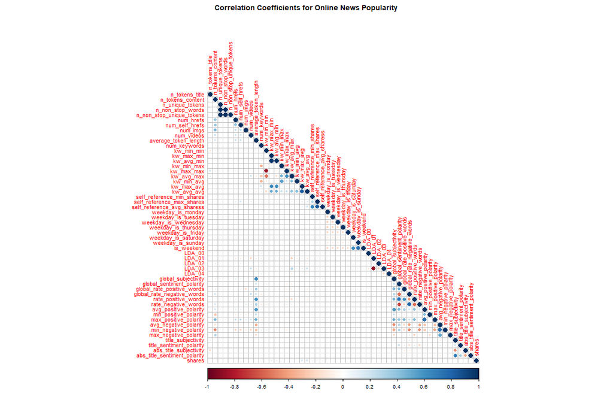

```r
knitr::include_graphics("corrplot.png")
```

Dark blue circles indicate there is a strong positive linear relationship between the variables, dark red indicates a strong negative linear relationship, and lighter shades of either color indicate weaker linear relationships. From the plot, the strongest linear relationships are between related variables, like each of the days of the week, different measures of keywords, or measures of polarity. The rest of the variables have weaker relationships, indicating there is little risk of multicollinearity if variables from different subject matters are chosen.

To aid in selection, a tibble of top correlations with the `shares` variable is generated. First, the names of the variables are taken from the correlation matrix using `row.names()`, then the values of the correlations across all variables with respect to `shares` is taken by using `bind_cols` and returning the `shares` column with index 53. The values are then sorted with `arrange()`, in descending order with `desc()`, and the top 20 rows are returned with `head()`. The tibble is then printed for viewing.

Variables are chosen from different subject matters to avoid colinearity, so from this list, one from each general area is selected, in addition to the target variable, then the subset of the data set is saved and a correlation matrix on the subset is printed as a data frame.

Another correlation plot is generated on the smaller set of variables using `corrplot()`, and we can confirm that the variables are within acceptable ranges of correlation to each other.

```r
top_cors <- cor_mat %>%
  row.names() %>%
  bind_cols("values" = cor_mat[ ,53]) %>%
  arrange(desc(values)) %>%
  head(n = 20)
top_cors
```

```
## # A tibble: 20 × 2
##    ...1                         values
##    <chr>                         <dbl>
##  1 shares                       1
##  2 kw_avg_avg                   0.174
##  3 kw_max_avg                   0.160
##  4 kw_max_min                   0.140
##  5 kw_avg_min                   0.120
##  6 self_reference_avg_sharess   0.0953
##  7 self_reference_min_shares    0.0786
##  8 self_reference_max_shares    0.0743
##  9 num_hrefs                    0.0468
## 10 num_keywords                 0.0397
## 11 num_imgs                     0.0381
## 12 global_subjectivity          0.0375
## 13 kw_avg_max                   0.0365
## 14 LDA_03                       0.0339
## 15 is_weekend                   0.0333
## 16 weekday_is_sunday            0.0307
## 17 kw_min_avg                   0.0283
## 18 title_subjectivity           0.0252
## 19 abs_title_sentiment_polarity 0.0251
## 20 avg_positive_polarity        0.0241
```

```r
subset_channel <- channel %>%
  select(kw_avg_avg, self_reference_avg_sharess, num_hrefs, num_imgs,
         global_subjectivity, is_weekend, avg_positive_polarity, shares)
data.frame(cor(subset_channel))
```

```
##                             kw_avg_avg self_reference_avg_sharess  num_hrefs
## kw_avg_avg                  1.00000000                 0.16949046 0.01982871
## self_reference_avg_sharess  0.16949046                 1.00000000 0.06047218
## num_hrefs                   0.01982871                 0.06047218 1.00000000
## num_imgs                    0.04069276                 0.03174652 0.23874596
## global_subjectivity        -0.02712328                 0.08306584 0.12997312
## is_weekend                  0.03008688                 0.01538669 0.03088086
## avg_positive_polarity      -0.02093730                 0.07360871 0.12462748
## shares                      0.17427644                 0.09533648 0.04676477
##                               num_imgs global_subjectivity   is_weekend
## kw_avg_avg                  0.04069276        -0.027123277  0.030086879
## self_reference_avg_sharess  0.03174652         0.083065836  0.015386687
## num_hrefs                   0.23874596         0.129973117  0.030880861
## num_imgs                    1.00000000        -0.039068662  0.051025070
## global_subjectivity        -0.03906866         1.000000000 -0.007586889
## is_weekend                  0.05102507        -0.007586889  1.000000000
## avg_positive_polarity       0.05001743         0.570670468 -0.006109662
## shares                      0.03809298         0.037510809  0.033265253
##                            avg_positive_polarity     shares
## kw_avg_avg                          -0.020937297 0.17427644
## self_reference_avg_sharess           0.073608710 0.09533648
## num_hrefs                            0.124627483 0.04676477
## num_imgs                             0.050017428 0.03809298
## global_subjectivity                  0.570670468 0.03751081
## is_weekend                          -0.006109662 0.03326525
## avg_positive_polarity                1.000000000 0.02407120
## shares                               0.024071204 1.00000000
```

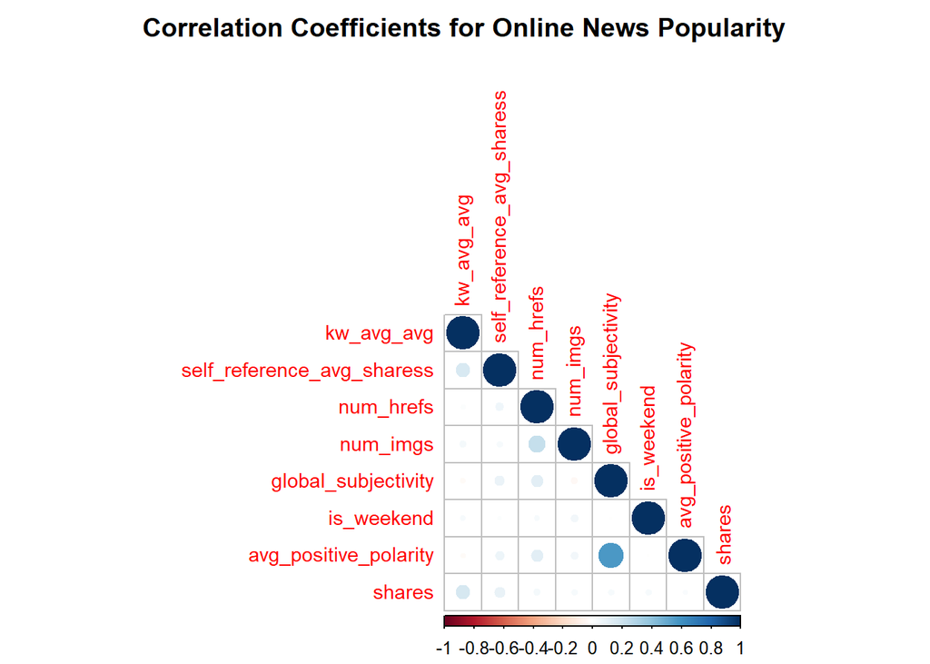

```r
corrplot(cor(subset_channel),
         type = "lower",
         tl.pos = "ld",
         tl.cex = 0.9,
         mar = c(0, 0, 2, 0),
         title = "Correlation Coefficients for Online News Popularity",
)
```

## Histogram

To look at some other summaries of the data, it may be useful to consider the distribution of the response variable. First, five number summaries of all of the variables of interest are taken with the `summary()` function. Means greater than comparative medians could indicate positive skew, and extremely large maximum values in relation to the other percentiles could be a sign of heavy skew. Means lower than comparative medians could indicate negative skew.

A histogram of the number of shares is generated with `ggplot()`. The range of share values is mapped to the x axis via `aes()` argument, and the base plotting object is saved. From the base object, a histogram layer is added with `geom_histogram()`. The color is set to red via `fill` argument, and a title is added using its respective argument in the `labs()` layer. If the histogram is skewed to the right, that indicates that most articles have fewer shares across the full range of number of shares, and fewer articles have many shares. If the peak is in the middle, it would indicate that most articles are in the middle of the spectrum in terms of share counts, and if it the peak is on the right, it indicates that most articles are highly shared and fewer are less shared.

```r
summary(subset_channel)
```

```
##    kw_avg_avg    self_reference_avg_sharess   num_hrefs         num_imgs
##  Min.   :    0   Min.   :     0             Min.   :  0.00   Min.   :  0.000
##  1st Qu.: 2551   1st Qu.:  1048             1st Qu.:  4.00   1st Qu.:  1.000
##  Median : 2967   Median :  2035             Median :  7.00   Median :  1.000
##  Mean   : 3156   Mean   :  5039             Mean   : 10.69   Mean   :  6.318
##  3rd Qu.: 3553   3rd Qu.:  4870             3rd Qu.: 13.00   3rd Qu.:  8.000
##  Max.   :36023   Max.   :346100             Max.   :304.00   Max.   :128.000
##  global_subjectivity   is_weekend     avg_positive_polarity     shares
##  Min.   :0.0000      Min.   :0.0000   Min.   :0.0000        Min.   :    47
##  1st Qu.:0.4120      1st Qu.:0.0000   1st Qu.:0.3186        1st Qu.:   833
##  Median :0.4632      Median :0.0000   Median :0.3721        Median :  1200
##  Mean   :0.4520      Mean   :0.1298   Mean   :0.3658        Mean   :  2970
##  3rd Qu.:0.5119      3rd Qu.:0.0000   3rd Qu.:0.4224        3rd Qu.:  2100
##  Max.   :1.0000      Max.   :1.0000   Max.   :1.0000        Max.   :210300
```

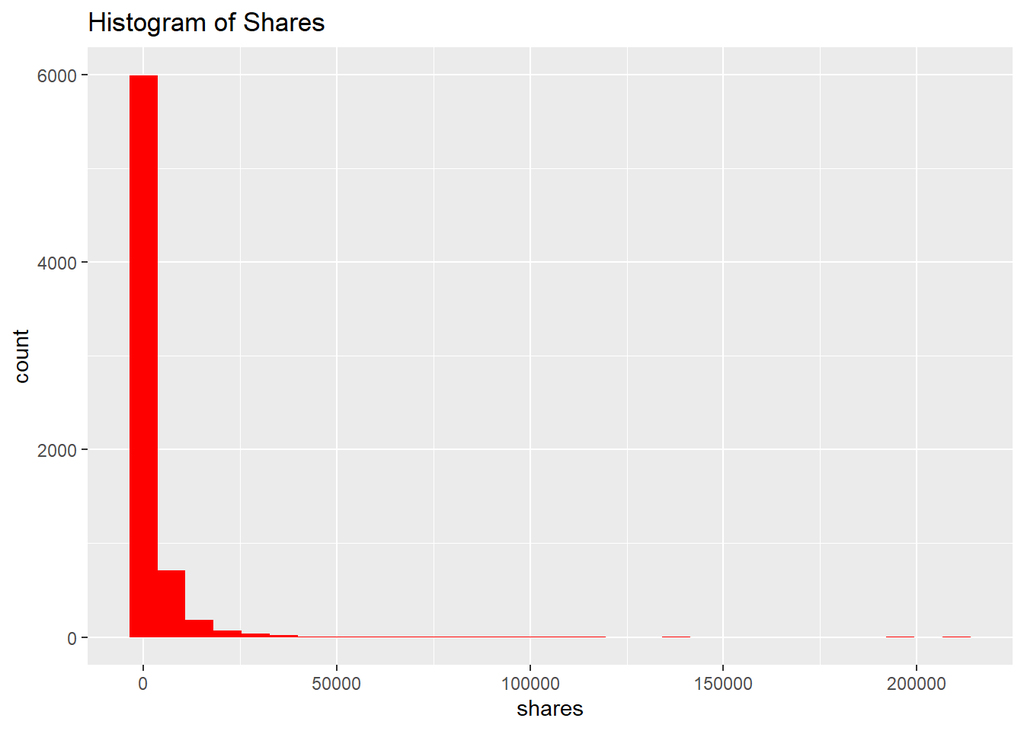

```r
g <- ggplot(data = subset_channel, aes(x = shares))
g + geom_histogram(fill = "red") +
  labs(title = "Histogram of Shares")
```

## Contingency Table

It might be interesting to look at the number of shares depending on whether the article was published on a weekend or not. To view the `share` variable in another way, it can be divided along its quartiles with the `cut()` function. Taking the `shares` variable as its first argument, `cut()` then uses `quantile()` to split up the variable into value ranges, taking a vector of quantiles with the `probs()` argument. The object is saved, and used in the `table()` function to make a contingency table against the `is_weekend` variable. `rbind()` takes the table and uses `apply()` to add the proportion of number of weekend shares of the total split. The `MARGIN` argument is set to 2 to indicate column proportions are being calculated, and the `FUN` argument takes in the function to apply: in this case, the number of weekend shares divided by the sum of shares for the split, rounded to 3 decimals. Proportions trending higher from left to right indicate that it is more common for articles with higher shares to be published on a weekend for that particular data channel, and proportions trending lower from left to right indicate the converse. If neither case is true, there may be no clear pattern.

```r
quart_shares <- cut(subset_channel$shares,
                    breaks = quantile(subset_channel$shares,
                                      probs = c(0, 0.25, 0.5, 0.75, 1)))
tab <- table(subset_channel$is_weekend, quart_shares)
rbind(tab, apply(tab, MARGIN = 2, FUN = function(x){round(x[2] / sum(x), 3)}))
```

```
##   (47,833] (833,1.2e+03] (1.2e+03,2.1e+03] (2.1e+03,2.1e+05]
## 0 1713.000       1854.00          1181.000          1392.000
## 1   57.000        228.00           286.000           345.000
##      0.032          0.11             0.195             0.199
```

## Box plot

Another interesting grouping is to examine shares by the number of images. Many articles do not use images at all, so it may be interesting to contrast those that do with those that do not. The `cut()` function is used to split the variable of interest again, this time from 0 to 1 or more. The `labels` argument is used to give labels for cleaner plots, and `right` is set to `FALSE` to make the splits exclude the right value, meaning 0 is the first split, and the second split starts at 1. A base plotting object is created again, this time mapping the cut variable `img_split` on the x axis, and the number of shares on the y axis. A box plot layer is added with `geom_boxplot()`, mapping the split levels as the color. Labels for the x axis added and title are added with the `labs()` function.

Because the distribution of shares could be highly skewed, there may be many outliers and the box plot may not be visually appealing or useful. Although outliers should not be removed without cause, to gain a better view of the data, a consideration may be to view the box plot without them. A similar box plot with the same syntax, but adding a coordinate layer with `coord_cartesian()` is generated, specifying the `ylim` argument to range from 0 to the 90th percentile of `shares` to show a better scale that hides some outliers. Many points above the boxes, a long tail above the box plots, or the median line being located towards the bottom of the boxes could indicate positive skew. Points towards the bottom would, a long tail below the box plots, or the median line being indicated towards the top of the boxes could indicate negative skew. Relatively symmetric tails, a median close to the center of the boxes, and few outliers would indicate a symmetric distribution.

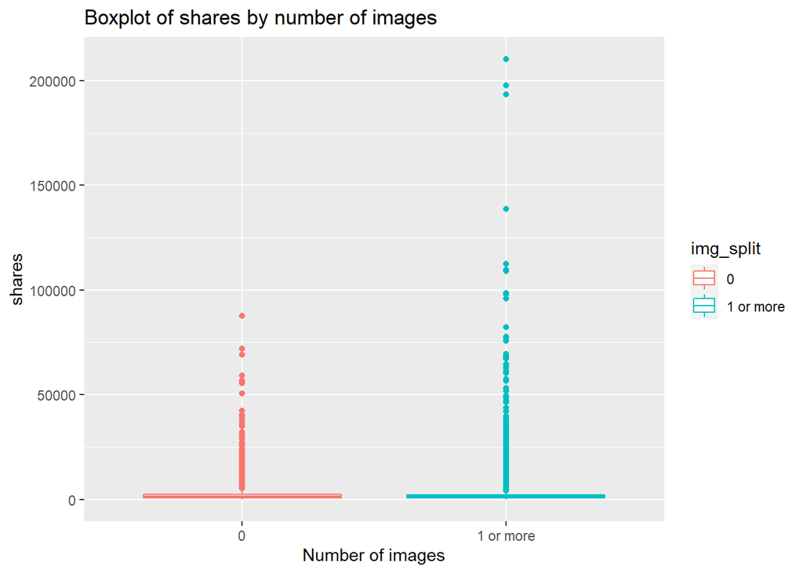

```r
img_split <- cut(subset_channel$num_imgs,
                 breaks = c(-Inf, 1, Inf),
                 labels = c("0", "1 or more"),
                 right = FALSE)
g <- ggplot(data = subset_channel, aes(x = img_split, y = shares))
g + geom_boxplot(aes(color = img_split)) +
  labs(title = "Boxplot of shares by number of images",
       x = "Number of images")
```

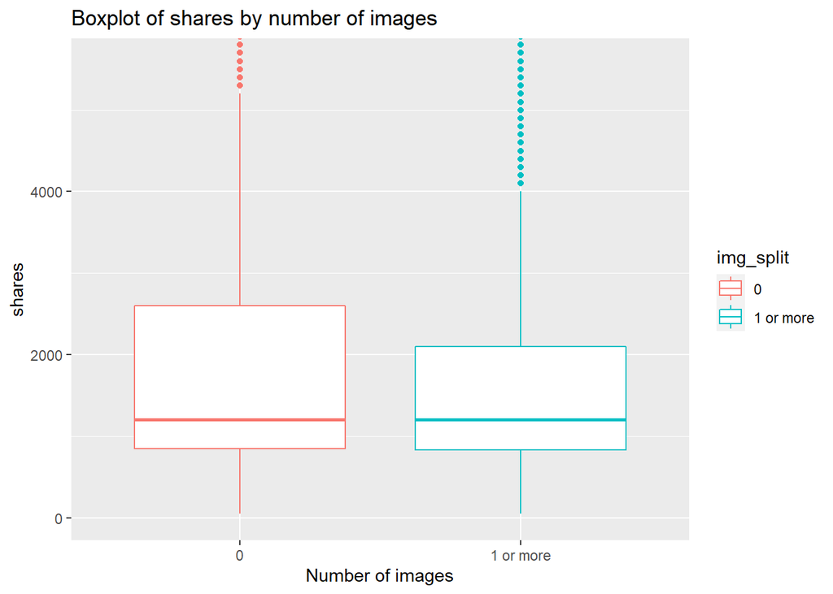

```r
g <- ggplot(data = subset_channel, aes(x = img_split, y = shares))
g + geom_boxplot(aes(color = img_split)) +
  labs(title = "Boxplot of shares by number of images",
       x = "Number of images") +
  coord_cartesian(ylim = c(0, quantile(subset_channel$shares, 0.90)))
```

# Modeling

## Regression

To model the data, first it needs to be split into a training set and test set. The `createDataPartition()` takes the `shares` variable and samples 70% of the indices by passing 0.7 to the `p` argument, and lastly, outputs the results as a matrix by setting the `list` argument to `FALSE`. The indices are saved and used to subset the data set on the variables of interest by using the `[` function and accessing the indices as the rows. The training set is saved, and the same method is used to obtain a test set, but using the `-` function to access the indices that were not sampled.

The `train()` function fits a multiple linear regression model of `shares`, modeled by the remaining main effect terms of the variables chosen during the correlation section above. The data used is the training set, and the `method` argument is passed “lm” to indicate a linear model. The model is saved as `mlr`.

**Aside**: Linear regression is a supervised learning technique where the value of the of a response variable is modeled or predicted by an explanatory variable by fitting a linear equation to observed data. The equation of the line can be modeled generically by: `Y~i~ = B~0~ + B~1~x~i~ + E~i~ where Y~i~` is the response for the i<sup>th</sup> observation, `x~i~` is the value of the explanatory variable for the i<sup>th</sup> observation, `B~0~` is the y-intercept, `B~1~` is the slope, and `E~i~` is the error. The line of best fit is found by minimizing the sum of squared differences between the observed values and the predicted values on the line itself.

The modeled regression line is used to predict on the test data set using the `predict()` function. Those predictions are then evaluated for prediction error by being passed as the first argument of `postResample()` with the actual `shares` observations as the second argument. RMSE, Rsquared, and MAE are output.

A second multiple linear regression model is fitted, predicted on, and evaluated using the same methodology and syntax, but uses all main effects and all interaction terms via `~.^2` in the formula argument.

```r
dataIndex <- createDataPartition(subset_channel$shares, p = 0.7, list = FALSE)
dataTrain <- subset_channel[dataIndex, ]
dataTest <- subset_channel[-dataIndex, ]

mlr <- train(shares ~., data = dataTrain, method ="lm")
pmlr <- predict(mlr, newdata = dataTest)
postResample(pmlr, dataTest$shares)
```

```
##         RMSE     Rsquared          MAE
## 7584.3799801    0.0129302 2748.7924164
```

```r
mlr2<- train(shares ~.^2, data = dataTrain, method ="lm")
pmlr2<- predict(mlr2, newdata = dataTest)
postResample(pmlr2, dataTest$shares)
```

```
##         RMSE     Rsquared          MAE
## 7.662948e+03 1.470336e-02 2.831112e+03
```

## Ensemble Tree Methods

### Random Forest

**Explanation:** A random forest model is an ensemble learning method where many trees are fitted and their results are averaged. The basic concept is that given a sample, that sample is resampled in the same manner as the original repeatedly. The samples are taken with replacement, so that duplicate observations may be present, and some observations may be omitted. A tree is then trained on each sample, called a bootstrap sample, using a random subset of the variables. This is done to reduce variance; if a dominant predictor is present most of the trees will use the same first splits, and will be highly correlated. After all of the predictions are done, the final predictions are the average of all the individual tree predictions, or if using a classification prediction, the final prediction is the majority vote by all trees.

Before fitting the tree model, a random number generator seed is first set to reproduce the random aspects of the training. The `train()` function then takes in the response modeled by all predictors. The `data` argument passes the training set and `method` specifies `rf` for random forest. `trControl` passes training parameters, produced by the `trainControl()` argument, where `method` and `number` specify the resampling method as cross validation and the number of folds, respectively. `preProcess` passes a vector of `"center"` and `"scale"` to center and scale the data, and those values are saved and also used to process the testing data later. `tuneGrid` passes a data frame of tuning parameters; for random forests, the parameters are the number of random variables to try, labeled as `mtry`, and given as a sequence. The fit is then saved.

```r
#random Forest
#updated number to 3 to run faster, can change to 5 before submission.
set.seed(99)
rfFit <- train(shares ~ ., data = dataTrain,
               method = "rf",
               trControl = trainControl(method = "cv",
                                        number = 3),
               preProcess = c("center", "scale"),
               tuneGrid = data.frame(mtry = 1:6))

pred <- predict(rfFit, newdata = dataTest)
postResample(pred, dataTest$shares)
```

[output not shown]

### Boosted Trees

**Explanation:** A boosted tree model is an ensemble learning method wherein trees are fitted sequentially, and each tree is fitted based on the previous one, updated by predictions each time. The general concept is that the trees are fitted, given a specified number of splits, based on residuals of predictions that are updated slowly. In detail, first the predictions are initialized to 0, then the residuals are calculated, then trees are fitted on the residuals, then the predictions are updated to the predictions prior to the residuals prior to the fitting plus the new predictions multiplied by a shrinkage parameter to slow the growth. Then, the residuals to fit the next tree on are updated from the new predictions, an the process repeats until a predefined stopping point.

Before fitting the boosted tree, a grid of tuning parameters is generated with the `expand.grid()` function, which outputs all possible combinations of the vectors passed. This fits trees on each combination so that the best model can be chosen. Because they are being used in the `tuneGrid` argument, the vectors are named explicitly. The tuning parameters are as follows:

- `n.trees` is the number of trees to fit sequentially.
- `interaction.depth` is the maximum depth of each tree, or the highest level of variable interactions allowed.
- `shrinkage` is the shrinkage parameter, or the multiplier to use to update predictions after each sequential fit.
- `n.minobsinnode` is the minimum number of observations allowed in the terminal nodes of each tree.

The grid is saved, and then the `trainControl()` function again chooses the training parameters, this time with 10 folds. The `gbm` package is then read in to be used with the `train()` function, and the random number generator seed is reset. The `train()` function uses the same syntax before, but this time indicates `"gbm"` as the method, the `tuneGrid` argument is passed the expanded grid, and `verbose` is set to `FALSE` to hide the outputs of every fit. The predictions are then generated and evaluated using the same syntax and methodology previously.

```r
caretGrid <- expand.grid(interaction.depth = c(1,2,3,4),
                         n.trees = c(25,50,100,150,200),
                         shrinkage = 0.1,
                         n.minobsinnode = 10)
trainControl <- trainControl(method ="cv", number = 10)

library(gbm)
set.seed(99)
btFit <- train(shares ~ ., data = dataTrain,
               method = "gbm",
               trControl = trainControl,
               preProcess = c("center", "scale"),
               tuneGrid = caretGrid,
               verbose = FALSE)

btpred <- predict(btFit, newdata = dataTest)
postResample(btpred, dataTest$shares)
```

```
##         RMSE     Rsquared          MAE
## 7.589586e+03 1.054946e-02 2.736004e+03
```